# Atividade 5/7 - Propensity Score Matching

Raphael Vieira dos Santos - matrícula: 190152974

Atividade 5/7 da disciplina **Laboratório de Econometria**, professor **Rafael Terra**, ofertada no semestre 2023/2.

## Situação Problema

A partir da aplicação do programa social **Bolsa Família**, o problema a seguir consiste em verificar qual o impacto do tratamento do programa sobre as horas trabalhadas do indivíduo “i” e sobre sua renda familiar, partindo de um banco de dados coletado pela PNAD para o ano de 2006. Nesse caso, estabeleceremos um critério sintético para participação no programa do bolsa família para grupos cuja renda familiar seja menor ou igual a R$ 350 (equivalendo ao salário mínimo em Abril de 2006, conforme a Medida Provisória nº 288, de 2006).

> `horas_trabalhadas` = α + β1 * `PBF` + β2 * `idade` + β3 * `idade2` + β4 * `anos_estudo` + β5 * `anos_estudo2` + β6 * `dummy_sexo` + β7 * `dummy_raca` + β8 * `dummy_casado` + β9 * `dummy_rural` + β10 * `renda_domiciliar` + ε

Antes de usar o comando, pede-se que seja definida uma “semente aleatória” igual ao número de matrícula na UnB (isso permite replicar exatamente os resultados cada vez que o comando for estimado novamente). Restrinja as observações ao suporte comum.

## Sobre o Método *Propensity Score Matching (PSM)*

O Propensity Score Matching (PSM) é uma técnica estatística usada para reduzir o viés de seleção em estudos observacionais. Em estudos observacionais, os pesquisadores não têm controle sobre a alocação dos tratamentos, e a possibilidade de viés de seleção é alta. O PSM tenta equilibrar as características observáveis entre os grupos de tratamento e controle, tornando os grupos mais comparáveis.

A ideia central do PSM é calcular o escore de propensão para cada unidade observacional, que é a probabilidade de receber o tratamento com base em suas características observáveis. Depois de calcular esses escores de propensão, as unidades no grupo de tratamento são pareadas com unidades no grupo de controle que têm escores de propensão semelhantes. Essa abordagem ajuda a criar grupos que são comparáveis em termos de características observáveis, tornando mais plausível a inferência causal sobre os efeitos do tratamento.

## Carregando os pacotes e funções de interesse

```r
rm(list=ls())

library(ggplot2)
library(glmnet)
library(dplyr)
library(haven)
library(Matching)
library(foreign)
library(stargazer)
library(texreg)
library(sandwich)
library(lmtest)
library(mfx)
library(miceadds)
library(tidyverse)
library(AER)
library(car)
library(survival)
library(MatchIt)
library(MatchItSE)
```

## Carregando o banco de dados

```r
PNAD2006 <- read_dta(path)

# Variáveis de interesse
variaveis_interesse <- c("v0302", "v8005", "v0401", "v0402", "v0404", "v9001",
                         "v9058", "v9101", "v9105", "v4703", "v4705",
                         "v4718", "v4719", "v4721", "v4723", "v4728", "v4741")

# Novo dataframe
df_PNAD2006 <- PNAD2006[, variaveis_interesse]

# Variável "idade" e "idade2" a partir de "v8005"
df_PNAD2006$idade <- PNAD2006$v8005
df_PNAD2006$idade2 <- df_PNAD2006$idade^2

# Variável "anos_estudo" e "anos_estudo2" a partir de "v4703"
df_PNAD2006$anos_estudo <- PNAD2006$v4703
df_PNAD2006$anos_estudo2 <- df_PNAD2006$anos_estudo^2

# Variável "dummy_sexo" a partir de "v0302", sendo 1 = "homem" e 0 = "mulher"
df_PNAD2006$dummy_sexo <- ifelse(PNAD2006$v0302 == 2, 1, 0)

# Variável "dummy_raca" a partir de "v0404", sendo 1 = "pretos/pardos/indígenas" e 0 = "brancos/amarelos"
df_PNAD2006$dummy_raca <- ifelse(PNAD2006$v0404 %in% c(4, 8, 0, 9), 1, 0)

# Variável "dummy_casado" a partir de "v0401", sendo 1 = "casado", e 0 = "não casado"
df_PNAD2006$dummy_casado <- ifelse(PNAD2006$v0401 == 2, 1, 0)

# Variável "dummy_rural" a partir de "v4728", sendo 1 = "rural", e 0 = "urbano"
df_PNAD2006$dummy_rural <- ifelse(PNAD2006$v4728 %in% c(1, 2, 3), 0, 1)

# Variável "renda_domiciliar" a partir de "v4721"
df_PNAD2006$renda_domiciliar <- PNAD2006$v4721

# Variável "horas_trabalhadas" somando "v9058", "v9101" e "v9105"
df_PNAD2006$horas_trabalhadas <- rowSums(PNAD2006[, c("v9058", "v9101", "v9105")], na.rm = TRUE)

# Variável de tratamento "PBF" com base no critério de renda
df_PNAD2006$PBF <- ifelse(df_PNAD2006$renda_domiciliar <= 350, 1, 0)

variaveis_interesse <- c("PBF", "idade", "idade2", "anos_estudo", "anos_estudo2", "dummy_sexo", "dummy_raca",
                                      "dummy_casado", "dummy_rural", "renda_domiciliar",
                                      "horas_trabalhadas")

df_PNAD2006 <- df_PNAD2006[, variaveis_interesse]

# Restringir ao suporte comum (Common Support)
common_support <- subset(df_PNAD2006, renda_domiciliar <= 350)
common_support$id<-row.names(common_support)
common_support <- subset(common_support, complete.cases(common_support))
common_support$id<-as.numeric(as.character(common_support$id))
```

## Efetuando o *Propensity Score Matching (PSM)*

```r
set.seed(190152974)

# Criando variável aleatória para garantir aleatoriedade na aplicação do tratamento
df_PNAD2006$aleatorio <- runif(nrow(df_PNAD2006))

# Recriando a variável PBF com critério mais específico (por exemplo, renda até R$ 350 e aleatoriedade baseada no número da matrícula)
df_PNAD2006$PBF <- ifelse(df_PNAD2006$renda_domiciliar <= 350 & df_PNAD2006$aleatorio < 0.5, 1, 0)

# Restringindo ao suporte comum (Common Support)
common_support <- subset(df_PNAD2006, renda_domiciliar <= 350)

# Substituindo 'variavel_PBF' pela variável real do programa Bolsa Família
psm_data <- subset(common_support, select = c("PBF", "idade", "idade2", "anos_estudo", "anos_estudo2",
                                              "dummy_sexo", "dummy_raca", "dummy_casado", "dummy_rural",
                                              "renda_domiciliar", "horas_trabalhadas"))

# Substituindo 'variavel_PBF' pela variável real do programa Bolsa Família
psm_data$PBF <- as.factor(psm_data$PBF)
levels(psm_data$PBF) <- c("0", "1")  # Certifique-se de que os níveis são 0 e 1

# Definindo as covariadas para o modelo PSM
ps_covariates <- c("idade", "idade2", "anos_estudo", "anos_estudo2",
                   "dummy_sexo", "dummy_raca", "dummy_casado", "dummy_rural",
                   "renda_domiciliar")

# Estimando o modelo PSM
psm_model <- matchit(
  formula = PBF ~ idade + idade2 + anos_estudo + anos_estudo2 +
    dummy_sexo + dummy_raca + dummy_casado + dummy_rural + renda_domiciliar,
  data = psm_data,
  method = "nearest",
  ratio = 1,  # 1:1 matching
  discard = "both"
)

psm_data$propensity_score <- psm_model$distance

summary(psm_model)
```

```
##
## Call:
## matchit(formula = PBF ~ idade + idade2 + anos_estudo + anos_estudo2 +
##     dummy_sexo + dummy_raca + dummy_casado + dummy_rural + renda_domiciliar,
##     data = psm_data, method = "nearest", discard = "both", ratio = 1)
##
## Summary of Balance for All Data:
##                  Means Treated Means Control Std. Mean Diff. Var. Ratio
## distance                0.5030        0.5028          0.0300     0.9298
## idade                  26.6854       27.0511         -0.0181     0.9690
## idade2               1122.4332     1155.1902         -0.0223     0.9402
## anos_estudo             4.3606        4.3603          0.0001     1.0084
## anos_estudo2           31.7348       31.6260          0.0024     1.0219
## dummy_sexo              0.4807        0.4792          0.0031          .
## dummy_raca              0.6930        0.6938         -0.0018          .
## dummy_casado            0.1703        0.1713         -0.0026          .
## dummy_rural             0.3304        0.3299          0.0010          .
## renda_domiciliar      239.6954      239.1425          0.0051     0.9943
##                  eCDF Mean eCDF Max
## distance            0.0062   0.0112
## idade               0.0037   0.0092
## idade2              0.0037   0.0092
## anos_estudo         0.0012   0.0041
## anos_estudo2        0.0012   0.0041
## dummy_sexo          0.0015   0.0015
## dummy_raca          0.0008   0.0008
## dummy_casado        0.0010   0.0010
## dummy_rural         0.0005   0.0005
## renda_domiciliar    0.0022   0.0080
##
## Summary of Balance for Matched Data:
##                  Means Treated Means Control Std. Mean Diff. Var. Ratio
## distance                0.5034        0.5028          0.0863     0.6706
## idade                  26.0211       27.0511         -0.0508     0.8877
## idade2               1052.9649     1155.1902         -0.0696     0.7616
## anos_estudo             4.3750        4.3603          0.0041     1.0117
## anos_estudo2           31.9024       31.6260          0.0062     1.0267
## dummy_sexo              0.4824        0.4792          0.0063          .
## dummy_raca              0.6947        0.6938          0.0020          .
## dummy_casado            0.1718        0.1713          0.0013          .
## dummy_rural             0.3321        0.3299          0.0046          .
## renda_domiciliar      238.6410      239.1425         -0.0046     0.9925
##                  eCDF Mean eCDF Max Std. Pair Dist.
## distance            0.0122   0.0182          0.0881
## idade               0.0102   0.0179          0.8228
## idade2              0.0102   0.0179          0.6109
## anos_estudo         0.0014   0.0038          1.0102
## anos_estudo2        0.0014   0.0038          0.8761
## dummy_sexo          0.0032   0.0032          0.9791
## dummy_raca          0.0009   0.0009          0.8778
## dummy_casado        0.0005   0.0005          0.7232
## dummy_rural         0.0022   0.0022          0.9349
## renda_domiciliar    0.0027   0.0096          0.8851
##
## Sample Sizes:
##           Control Treated
## All         24307   24587
## Matched     24307   24307
## Unmatched       0     276
## Discarded       0       4
```

```r
# Estimar o modelo Probit
probit_model <- glm(PBF ~ idade + idade2 + anos_estudo + anos_estudo2 +
                      dummy_sexo + dummy_raca + dummy_casado + dummy_rural + renda_domiciliar,
                    family = binomial(link = "probit"), data = psm_data)

# Exibir os resultados
summary(probit_model)
```

```
##
## Call:
## glm(formula = PBF ~ idade + idade2 + anos_estudo + anos_estudo2 +
##     dummy_sexo + dummy_raca + dummy_casado + dummy_rural + renda_domiciliar,
##     family = binomial(link = "probit"), data = psm_data)
##
## Deviance Residuals:
##    Min      1Q  Median      3Q     Max
## -1.224  -1.184   1.149   1.170   1.282
##
## Coefficients:
##                    Estimate Std. Error z value Pr(>|z|)
## (Intercept)       6.421e-03  2.235e-02   0.287   0.7739
## idade             1.766e-03  1.087e-03   1.624   0.1044
## idade2           -3.331e-05  1.475e-05  -2.258   0.0239 *
## anos_estudo      -7.777e-03  5.653e-03  -1.376   0.1689
## anos_estudo2      5.112e-04  4.304e-04   1.188   0.2349
## dummy_sexo        1.387e-05  1.242e-02   0.001   0.9991
## dummy_raca       -6.199e-03  1.239e-02  -0.500   0.6168
## dummy_casado     -7.697e-03  1.754e-02  -0.439   0.6607
## dummy_rural      -1.796e-03  1.241e-02  -0.145   0.8850
## renda_domiciliar  6.330e-05  5.312e-05   1.192   0.2334
## ---
## Signif. codes:  0 '***' 0.001 '**' 0.01 '*' 0.05 '.' 0.1 ' ' 1
##
## (Dispersion parameter for binomial family taken to be 1)
##
##     Null deviance: 67780  on 48893  degrees of freedom
## Residual deviance: 67769  on 48884  degrees of freedom
## AIC: 67789
##
## Number of Fisher Scoring iterations: 3
```

O coeficiente associado a idade2 é estatisticamente significativo a 5%, indicando uma relação não linear significativa entre a idade e a probabilidade do tratamento. Outros coeficientes não apresentam significância estatística a 5%.

O modelo Probit não fornece uma interpretação direta dos coeficientes como o faz o modelo Logit. No entanto, as estimativas indicam a direção e magnitude do efeito das covariáveis na probabilidade do tratamento.

```r
# Antes do pareamento
before_matching <- t.test(horas_trabalhadas ~ PBF, data = df_PNAD2006)

# Depois do pareamento
after_matching <- t.test(horas_trabalhadas ~ PBF, data = psm_data)

# Exibir os resultados
summary(before_matching)
```

```
##             Length Class  Mode
## statistic   1      -none- numeric
## parameter   1      -none- numeric
## p.value     1      -none- numeric
## conf.int    2      -none- numeric
## estimate    2      -none- numeric
## null.value  1      -none- numeric
## stderr      1      -none- numeric
## alternative 1      -none- character
## method      1      -none- character
## data.name   1      -none- character
```

```r
summary(after_matching)
```

```
##             Length Class  Mode
## statistic   1      -none- numeric
## parameter   1      -none- numeric
## p.value     1      -none- numeric
## conf.int    2      -none- numeric
## estimate    2      -none- numeric
## null.value  1      -none- numeric
## stderr      1      -none- numeric
## alternative 1      -none- character
## method      1      -none- character
## data.name   1      -none- character
```

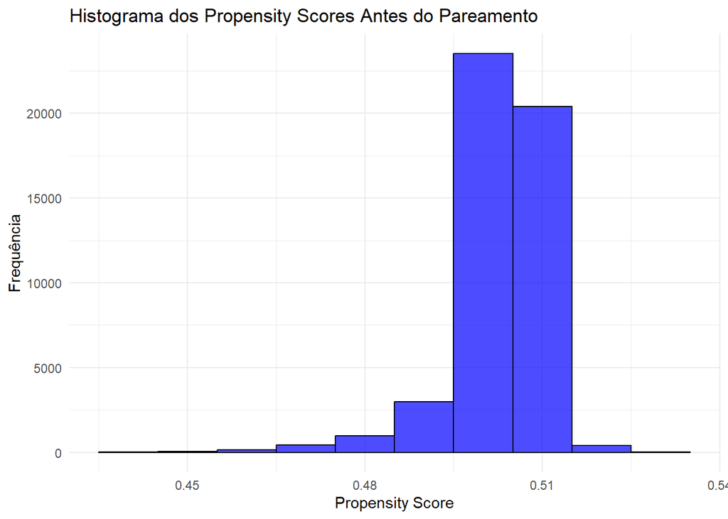

```r
# Antes do pareamento
hist_before_matching <- ggplot(psm_data, aes(x = propensity_score)) +
  geom_histogram(binwidth = 0.01, fill = "blue", color = "black", alpha = 0.7) +
  labs(title = "Histograma dos Propensity Scores Antes do Pareamento",
       x = "Propensity Score",
       y = "Frequência") +
  theme_minimal()

# Depois do pareamento
hist_after_matching <- ggplot(psm_data, aes(x = propensity_score)) +
  geom_histogram(binwidth = 0.01, fill = "green", color = "black", alpha = 0.7) +
  labs(title = "Histograma dos Propensity Scores Depois do Pareamento",
       x = "Propensity Score",
       y = "Frequência") +
  theme_minimal()

# Exibir os histogramas
print(hist_before_matching)
```

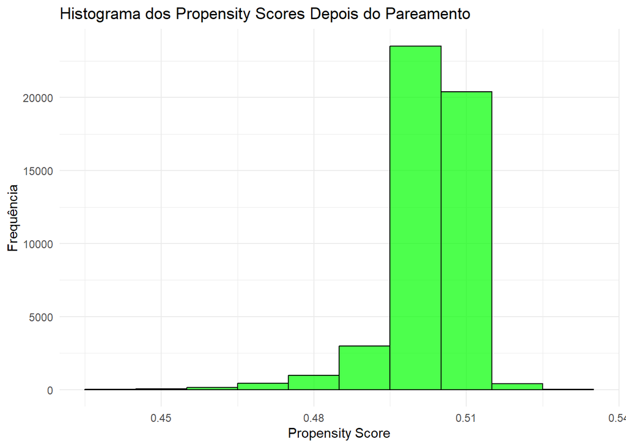

```r
print(hist_after_matching)
```

## Conclusão

Ao longo da análise, foram realizadas diversas etapas visando a estimação do efeito causal do tratamento pelo programa Bolsa Família (PBF) sobre a variável resposta. Inicialmente, foi observada a necessidade de redefinir a variável de tratamento, PBF, considerando critérios mais específicos, levando em conta não apenas a renda domiciliar, mas também a aleatoriedade associada ao número de matrícula (190152974).

Posteriormente, o processo de pareamento foi conduzido utilizando o método “nearest,” ajustando as covariáveis para equilibrar os grupos tratado e não tratado. O objetivo principal foi garantir a comparabilidade entre os dois grupos, reduzindo viés e possibilitando uma estimação mais precisa do efeito causal.